# Assignment 7: Visualization - Some aspects of ggplot2

*How to do it?*:

- Open the Rmarkdown file of this assignment (link) in Rstudio.
- Right under each **question**, insert a code chunk (you can use the hotkey `Ctrl + Alt + I` to add a code chunk) and code the solution for the question.
- `Knit` the rmarkdown file (hotkey: `Ctrl + Alt + K`) to export an html.
- Publish the html file to your Githiub Page.

*Submission*: Submit the link on Github of the assignment to Canvas

Use the data of your own. Produce the following types of plots and comment on each plot. Plots should be meaningful. If you use the data we used in class, make sure the plots are not the same as the ones in the slides. All plots should have title, caption, appropriate labels on x and y-axis.

1. Make a plot using `facet_wrap` by one categorical variable (`facet_wrap(~variable1)`)

```r
#Importing libraries and data. Source: https://www.kaggle.com/datasets/nelgiriyewithana/billionaires-statistics-dataset

library(tidyverse)
library(dplyr)
library(knitr)
library(ggplot2)

df <- read_csv('Billionaires Statistics Dataset.csv')
df
```

```
## # A tibble: 2,640 × 35
##     rank finalWorth category    personName   age country city  source industries
##    <dbl>      <dbl> <chr>       <chr>      <dbl> <chr>   <chr> <chr>  <chr>
##  1     1     211000 Fashion & … Bernard A…    74 France  Paris LVMH   Fashion &…
##  2     2     180000 Automotive  Elon Musk     51 United… Aust… Tesla… Automotive
##  3     3     114000 Technology  Jeff Bezos    59 United… Medi… Amazon Technology
##  4     4     107000 Technology  Larry Ell…    78 United… Lanai Oracle Technology
##  5     5     106000 Finance & … Warren Bu…    92 United… Omaha Berks… Finance &…
##  6     6     104000 Technology  Bill Gates    67 United… Medi… Micro… Technology
##  7     7      94500 Media & En… Michael B…    81 United… New … Bloom… Media & E…
##  8     8      93000 Telecom     Carlos Sl…    83 Mexico  Mexi… Telec… Telecom
##  9     9      83400 Diversified Mukesh Am…    65 India   Mumb… Diver… Diversifi…
## 10    10      80700 Technology  Steve Bal…    67 United… Hunt… Micro… Technology
## # ℹ 2,630 more rows
## # ℹ 26 more variables: countryOfCitizenship <chr>, organization <chr>,
## #   selfMade <lgl>, status <chr>, gender <chr>, birthDate <chr>,
## #   lastName <chr>, firstName <chr>, title <chr>, date <chr>, state <chr>,
## #   residenceStateRegion <chr>, birthYear <dbl>, birthMonth <dbl>,
## #   birthDay <dbl>, cpi_country <dbl>, cpi_change_country <dbl>,
## #   gdp_country <chr>, gross_tertiary_education_enrollment <dbl>, …
```

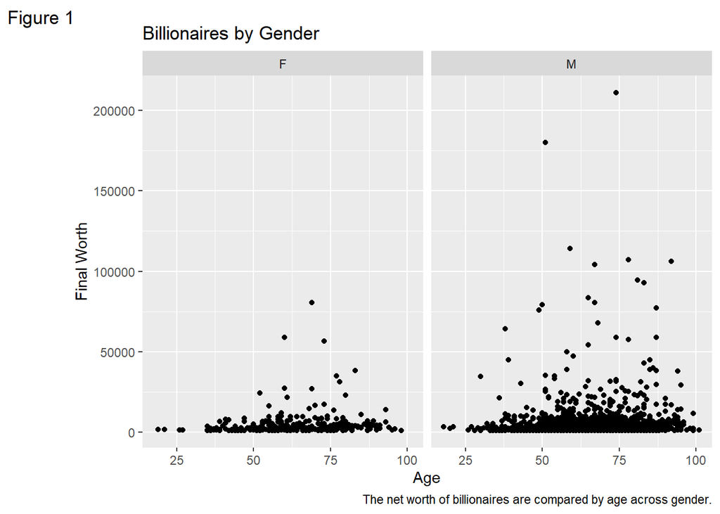

```r
#When comparing the richest man with the richest woman, they are 74 and 69 years old. The richest people in the world are mostly seniors between 60 to 80. Furthermore, this graph indicates that there are far more male billionaires. The top 10 richest people in the world are all male, and there are more points in the graph on the right. Note (the finalWorth is in millions)

df %>% ggplot()+
    geom_point(mapping=aes(x=age, y= finalWorth))+
  facet_wrap(~gender)+
  labs(title = "Billionaires by Gender",
       caption = "The net worth of billionaires are compared by age across gender.",
      tag = "Figure 1",x = "Age",y = "Final Worth")
```

2. Make a plot using `facet_wrap` by two categorical variables (`facet_wrap(~variable1+variable2)`)

```r
#Converting the class of selfMade from logical to character.

df$selfMade <- df$selfMade %>% ifelse('True','False')
df %>% head %>% select(selfMade)
```

```
## # A tibble: 6 × 1
##   selfMade
##   <chr>
## 1 False
## 2 True
## 3 True
## 4 True
## 5 True
## 6 True
```

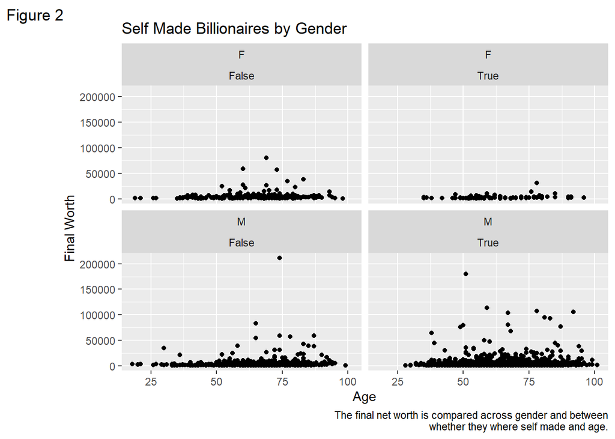

```r
#Using ggplot's facet_wrap function, the majority of male billionaires appear to be self made while the majority of female billionaires are not self made. The world's richest man and the world's richest woman are not self made. For some more detail on the variable `selfMade`, it is defined as someone who achieved their wealth without a large inheritance of wealth or status.

df %>% ggplot()+
  geom_point(mapping=aes(x=age, y=finalWorth ))+
  facet_wrap(~gender+selfMade)+
  labs(title = "Self Made Billionaires by Gender",
       caption = "The final net worth is compared across gender and between
       whether they where self made and age.",
      tag = "Figure 2",x = "Age",y = "Final Worth")
```

3. Make a plot using `position ='dodge'`.

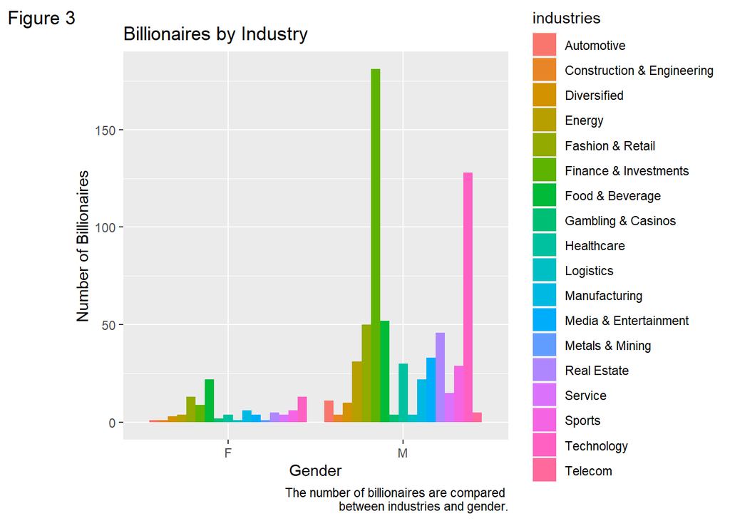

```r
#The argument `position = 'dodge'' is best used for comparing graphs of data side by side rather than overlapping. In comparison to fill, dodge makes it easier to compare quantities of variable categories.The most applicable plot to make for either fill or dodge is a bar plot. When comparing the industries of male and female billionaires in the U.S., the industries with the most male billionaires are finance & investments, and technology. The industries with the most female billionaires are food & beverage, fashion & retail, and technology.

df %>% filter(country == 'United States') %>% ggplot()+
  geom_bar(mapping=aes(x=gender, fill=industries),
           position = 'dodge')+
  labs(title = "Billionaires by Industry",
       caption = "The number of billionaires are compared
       between industries and gender.",
      tag = "Figure 3",x = "Gender",y = "Number of Billionaires")
```

4. Make a plot using `position ='fill'`.

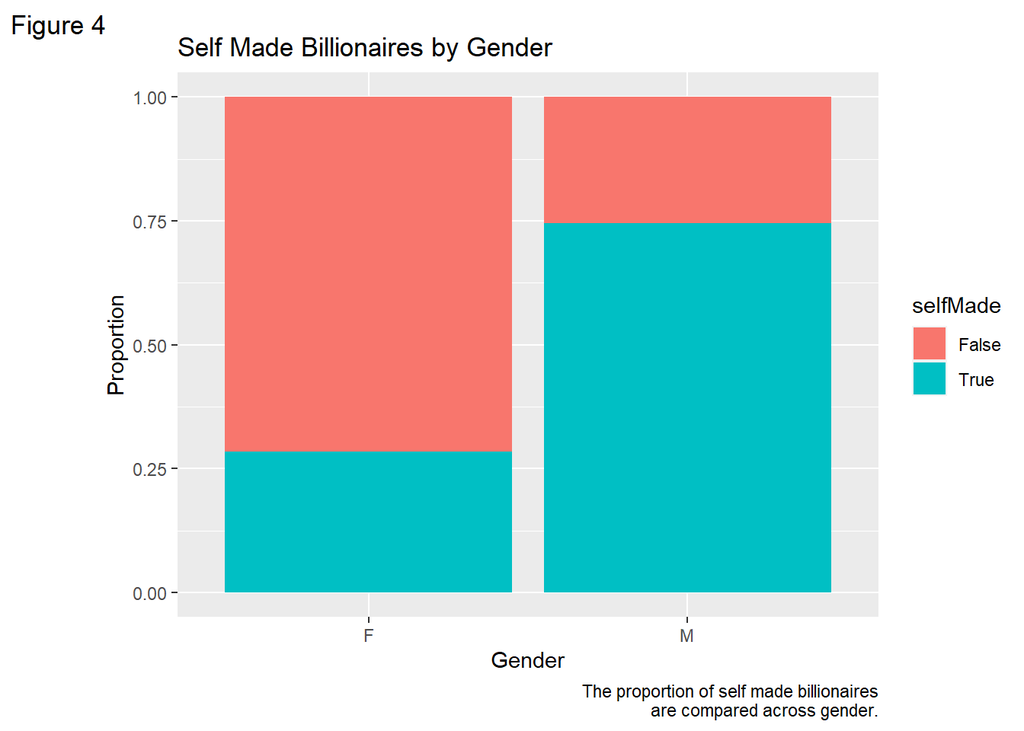

```r
#The barplot for self made billionaires by gender gives a much better illustration than the second graph of the proportion of self made billionaires between males and females.

df %>% ggplot()+
  geom_bar(mapping=aes(x=gender, fill=selfMade),
           position = 'fill')+
  labs(title = "Self Made Billionaires by Gender",
       caption = "The proportion of self made billionaires
       are compared across gender.",
      tag = "Figure 4",x = "Gender",y = "Proportion")
```

5. Make a plot using `geom_col`.

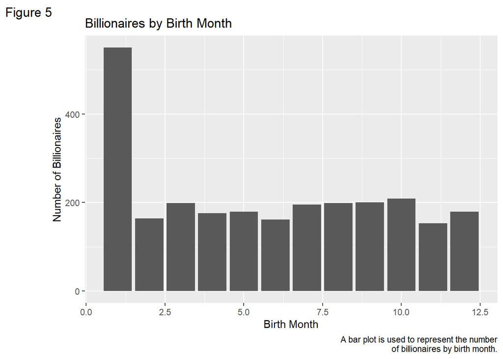

```r
#Interestingly, there is a very high number of billionaires born in the month of January in comparison to the other months. This behavior is strange since the number of billionaires born in January doubles even the second highest month.

df %>% ggplot()+
  geom_bar(mapping=aes(x=birthMonth))+
  labs(title = "Billionaires by Birth Month",
       caption = "A bar plot is used to represent the number
       of billionaires by birth month.",
      tag = "Figure 5",x = "Birth Month",y = "Number of Billionaires")
```

6. Change the theme of one of your plots.